# Improving Term Deposit Client Base

Leonardo Ji

2017-04-23

## Data

```r
bankFull<-read.csv("C:/Users/lj015625/Desktop/DataMining Class/HW5/data/bank-full.csv")
dim(bankFull)
```

```
## [1] 45211    17
```

```r
names(bankFull)
```

```
##  [1] "age..number"         "job..category"       "marital..category"
##  [4] "education..category" "default..category"   "balance..number"
##  [7] "housing..category"   "loan..category"      "contact..category"
## [10] "day..number"         "month..category"     "duration..number"
## [13] "campaign..number"    "pdays..number"       "previous..number"
## [16] "poutcome..category"  "y..category"
```

```r
summary(bankFull)
```

```
##   age..number        job..category  marital..category education..category
##  Min.   :18.00   blue-collar:9732   divorced: 5207    primary  : 6851
##  1st Qu.:33.00   management :9458   married :27214    secondary:23202
##  Median :39.00   technician :7597   single  :12790    tertiary :13301
##  Mean   :40.94   admin.     :5171                     unknown  : 1857
##  3rd Qu.:48.00   services   :4154
##  Max.   :95.00   retired    :2264
##                  (Other)    :6835
##  default..category balance..number  housing..category loan..category
##  no :44396         Min.   : -8019   no :20081         no :37967
##  yes:  815         1st Qu.:    72   yes:25130         yes: 7244
##                    Median :   448
##                    Mean   :  1362
##                    3rd Qu.:  1428
##                    Max.   :102127
##
##  contact..category  day..number    month..category duration..number
##  cellular :29285   Min.   : 1.00   may    :13766   Min.   :   0.0
##  telephone: 2906   1st Qu.: 8.00   jul    : 6895   1st Qu.: 103.0
##  unknown  :13020   Median :16.00   aug    : 6247   Median : 180.0
##                    Mean   :15.81   jun    : 5341   Mean   : 258.2
##                    3rd Qu.:21.00   nov    : 3970   3rd Qu.: 319.0
##                    Max.   :31.00   apr    : 2932   Max.   :4918.0
##                                    (Other): 6060
##  campaign..number pdays..number   previous..number   poutcome..category
##  Min.   : 1.000   Min.   : -1.0   Min.   :  0.0000   failure: 4901
##  1st Qu.: 1.000   1st Qu.: -1.0   1st Qu.:  0.0000   other  : 1840
##  Median : 2.000   Median : -1.0   Median :  0.0000   success: 1511
##  Mean   : 2.764   Mean   : 40.2   Mean   :  0.5803   unknown:36959
##  3rd Qu.: 3.000   3rd Qu.: -1.0   3rd Qu.:  0.0000
##  Max.   :63.000   Max.   :871.0   Max.   :275.0000
##
##  y..category
##  no :39922
##  yes: 5289
##
##
##
##
##
```

```r
table(bankFull$y..category)
```

```
##
##    no   yes
## 39922  5289
```

```r
set.seed(123)
trainIndex <- createDataPartition(bankFull$y..category, p = 0.9, list = FALSE, times = 1)
bankFull_train <- bankFull[ trainIndex,]
bankFull_validate <- bankFull[ -trainIndex,]
dim(bankFull_train) #checking the split
```

```
## [1] 40691    17
```

```r
dim(bankFull_validate) #checking the split
```

```
## [1] 4520   17
```

```r
prop.table(table(bankFull_train$y..category)) #checking to see the class proportions between the training and test sets.
```

```
##
##        no       yes
## 0.8829962 0.1170038
```

```r
prop.table(table(bankFull_validate$y..category))
```

```
##
##        no       yes
## 0.8831858 0.1168142
```

## Classification Models

We need supervised learning classification models to classify “y..category” variable. When this variable is yes this means clients subscribed term deposit.

### Model 1: Rpart Decision Tree

The decision tree model is the first model we want to use. We fit the whole training data set on a decision tree. We want a model has high Sensitivity $Sensitivity=\frac{True Positive}{True Positive + False Negative}$ because we want to predict clients who subscribed term deposit. Since we do not worry about predicting no “y..category” higher accuracy rate is not important to us. The kappa statistic $Kappa=\frac{Pr(a) - Pr(e)}{1-Pr(e)}$ adjusts accuracy by accounting for the possibility of a correct prediction by chance alone. We can compare Kappa statistic to know which model is better if both models have the same sensitivity.

```r
set.seed(123)
bank_yCat_rpart <- rpart(y..category ~., method="class", parms = list(split="gini"), minsplit = 20, data=bankFull_train)
cptable<-printcp(bank_yCat_rpart)
```

```
##
## Classification tree:
## rpart(formula = y..category ~ ., data = bankFull_train, method = "class",
##     parms = list(split = "gini"), minsplit = 20)
##
## Variables actually used in tree construction:
## [1] duration..number   poutcome..category
##
## Root node error: 4761/40691 = 0.117
##
## n= 40691
##
##         CP nsplit rel error  xerror     xstd
## 1 0.036617      0   1.00000 1.00000 0.013619
## 2 0.024785      3   0.89015 0.90338 0.013027
## 3 0.017853      4   0.86536 0.87083 0.012817
## 4 0.010000      5   0.84751 0.85675 0.012725
```

```r
cptable
```

```
##           CP nsplit rel error    xerror       xstd
## 1 0.03661696      0 1.0000000 1.0000000 0.01361853
## 2 0.02478471      3 0.8901491 0.9033816 0.01302652
## 3 0.01785339      4 0.8653644 0.8708255 0.01281685
## 4 0.01000000      5 0.8475110 0.8567528 0.01272451
```

```r
set.cp.value<-cptable[which.min(cptable[,"xerror"]),"CP"]
Pruned_bank_yCat_rpart <- prune(bank_yCat_rpart, cp=set.cp.value)
```

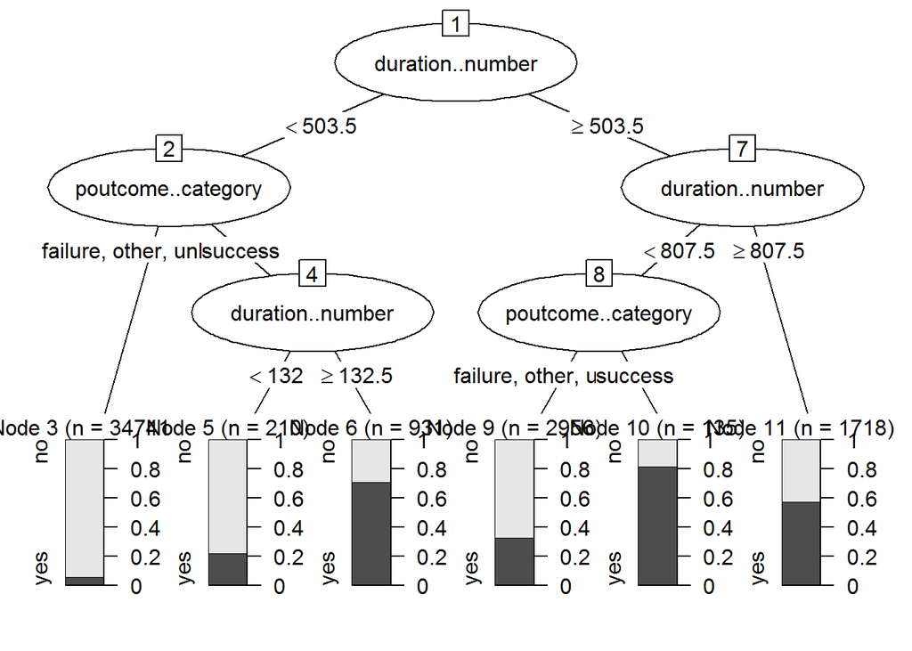

```r
#rpart.plot(Pruned_bank_yCat_rpart, type=0, extra=101)
#rpart.plot(Pruned_bank_yCat_rpart, type=1, extra=101)
# partykit looks better than rpart.plot
plot(as.party(Pruned_bank_yCat_rpart))
```

Finally we can use the decision tree model to predict “y:category” using validation data set and create a confusion matrix. The confusion matrix contains the number of rows we predicted correctly or incorrectly. From confusion matrix we can get sensitivity ratio. Even though we get a 90.18% overall accuracy rate, the sensitivity is only 36.93%. The decision tree model is not very good at predicting yes “y..category”. The decision tree model shows long duration contact, successful marketing campaing increase term deposit.

```r
# use a function to print result.
getResult<- function(bankFullModel, predictType, testData)
{
  actual <- testData$y..category
  predicted <- predict(bankFullModel, testData, type=predictType)
  results.matrix <- confusionMatrix(predicted, actual, positive="yes")
  print(results.matrix)
}

getResult(bank_yCat_rpart, "class", bankFull_validate)
```

```
## Confusion Matrix and Statistics
##
##           Reference
## Prediction   no  yes
##        no  3881  333
##        yes  111  195
##
##                Accuracy : 0.9018
##                  95% CI : (0.8927, 0.9103)
##     No Information Rate : 0.8832
##     P-Value [Acc > NIR] : 0.00003815
##
##                   Kappa : 0.4177
##  Mcnemar's Test P-Value : < 0.00000000000000022
##
##             Sensitivity : 0.36932
##             Specificity : 0.97219
##          Pos Pred Value : 0.63725
##          Neg Pred Value : 0.92098
##              Prevalence : 0.11681
##          Detection Rate : 0.04314
##    Detection Prevalence : 0.06770
##       Balanced Accuracy : 0.67076
##
##        'Positive' Class : yes
##
```

#### 10-fold cross validation

Cross validation is a technique that estimate model performance. Cross validation randomly divides training data set to ten folds. Then we select one fold as validation set and nine folds as training set to evaluate the model. Then we select a different validation set, rest of nine folds as training data set, and repeat this same process again for ten times until we get the best final model. After we run 10-fold cross validation the final decision tree model’s sensitivity is still low at 34.09%.

```r
# 10-fold cross validation
fitControl <- trainControl(method="cv", number=10)
set.seed(123)
bankFull_10folds<-train(y..category ~., data=bankFull_train, method="rpart", metric="Accuracy", trControl=fitControl)
#bankFull_10folds

getResult(bankFull_10folds, "raw", bankFull_validate)
```

```
## Confusion Matrix and Statistics
##
##           Reference
## Prediction   no  yes
##        no  3886  348
##        yes  106  180
##
##                Accuracy : 0.8996
##                  95% CI : (0.8904, 0.9082)
##     No Information Rate : 0.8832
##     P-Value [Acc > NIR] : 0.0002597
##
##                   Kappa : 0.3924
##  Mcnemar's Test P-Value : < 0.00000000000000022
##
##             Sensitivity : 0.34091
##             Specificity : 0.97345
##          Pos Pred Value : 0.62937
##          Neg Pred Value : 0.91781
##              Prevalence : 0.11681
##          Detection Rate : 0.03982
##    Detection Prevalence : 0.06327
##       Balanced Accuracy : 0.65718
##
##        'Positive' Class : yes
##
```

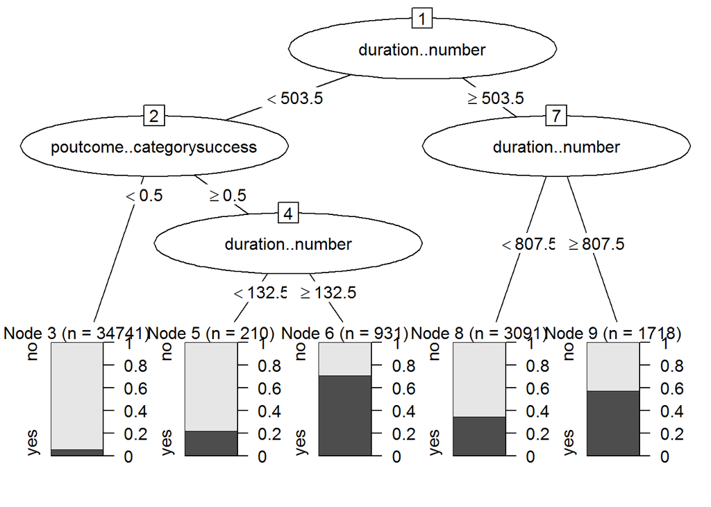

```r
bankFull_10folds_pruned<-prune(bankFull_10folds$finalModel, cp=0.01932367)
plot(as.party(bankFull_10folds_pruned))
```

#### 10-fold cross validation repeat 5 times

Sometimes repeating the cross validation improves result.  
However, we repeated 10-fold cross validation five times but we did not get a better sensitivity rate. We have the same result.

```r
# Repeated 10-fold cross validation
fitControl <- trainControl(method="cv", number=10, repeats=5)
set.seed(123)
bankFull_10folds_5repeat<-train(y..category ~., data=bankFull_train, method="rpart", metric="Accuracy", trControl=fitControl)
#bankFull_10folds_5repeat

getResult(bankFull_10folds_5repeat, "raw", bankFull_validate)
```

```
## Confusion Matrix and Statistics
##
##           Reference
## Prediction   no  yes
##        no  3886  348
##        yes  106  180
##
##                Accuracy : 0.8996
##                  95% CI : (0.8904, 0.9082)
##     No Information Rate : 0.8832
##     P-Value [Acc > NIR] : 0.0002597
##
##                   Kappa : 0.3924
##  Mcnemar's Test P-Value : < 0.00000000000000022
##
##             Sensitivity : 0.34091
##             Specificity : 0.97345
##          Pos Pred Value : 0.62937
##          Neg Pred Value : 0.91781
##              Prevalence : 0.11681
##          Detection Rate : 0.03982
##    Detection Prevalence : 0.06327
##       Balanced Accuracy : 0.65718
##
##        'Positive' Class : yes
##
```

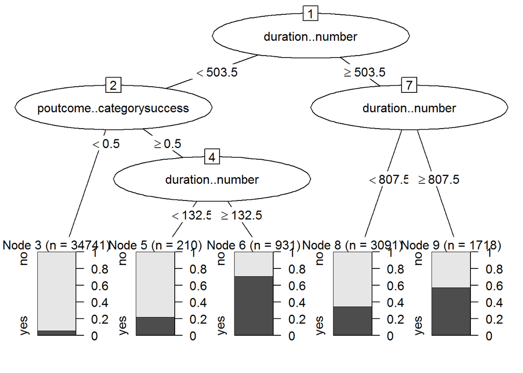

```r
bankFull_10folds_5repeat_pruned<-prune(bankFull_10folds_5repeat$finalModel, cp=0.01932367)
plot(as.party(bankFull_10folds_5repeat_pruned))
```

#### Boostrapping

Bootstrap sampling use random samples of data to estimate the larger data set. The result of ten random samples are averaged to obtain final result. Again we did not get a better sensitivity rate.

```r
# Bootstrapping
bootCtrl <- trainControl(method="boot", number=10) #10 bootstrapped samples.
set.seed(123)
bankFull_bootstrap<-train(y..category ~., data=bankFull_train, method="rpart", metric="Accuracy", trControl=bootCtrl)
#bankFull_bootstrap

getResult(bankFull_bootstrap, "raw", bankFull_validate)
```

```
## Confusion Matrix and Statistics
##
##           Reference
## Prediction   no  yes
##        no  3886  348
##        yes  106  180
##
##                Accuracy : 0.8996
##                  95% CI : (0.8904, 0.9082)
##     No Information Rate : 0.8832
##     P-Value [Acc > NIR] : 0.0002597
##
##                   Kappa : 0.3924
##  Mcnemar's Test P-Value : < 0.00000000000000022
##
##             Sensitivity : 0.34091
##             Specificity : 0.97345
##          Pos Pred Value : 0.62937
##          Neg Pred Value : 0.91781
##              Prevalence : 0.11681
##          Detection Rate : 0.03982
##    Detection Prevalence : 0.06327
##       Balanced Accuracy : 0.65718
##
##        'Positive' Class : yes
##
```

#### Bagging

The Ensemble methods are works well by using mutiple models for prediction. Bagging or bootstrap aggregating works by creating multiple Bootstrap samples and generate multiple decision tree models. The prediction is generated from voting or averaging from multiple decision tree models predictions. Bagging works well on unstable method like decision tree model. It gave us a slightly better sensitivity rate.

```r
# Bagging
library(ipred)
set.seed(123)
bankFull_bagging <- bagging(y..category ~., data = bankFull_train, nbagg = 100)
#bankFull_bagging
actual <- bankFull_validate$y..category
baggingPredicted <- predict(bankFull_bagging, newdata=bankFull_validate, type="class")
results.matrix <- confusionMatrix(baggingPredicted$class, actual, positive="yes")
print(results.matrix)
```

```
## Confusion Matrix and Statistics
##
##           Reference
## Prediction   no  yes
##        no  3890  336
##        yes  102  192
##
##                Accuracy : 0.9031
##                  95% CI : (0.8941, 0.9116)
##     No Information Rate : 0.8832
##     P-Value [Acc > NIR] : 0.00001077
##
##                   Kappa : 0.4186
##  Mcnemar's Test P-Value : < 0.00000000000000022
##
##             Sensitivity : 0.36364
##             Specificity : 0.97445
##          Pos Pred Value : 0.65306
##          Neg Pred Value : 0.92049
##              Prevalence : 0.11681
##          Detection Rate : 0.04248
##    Detection Prevalence : 0.06504
##       Balanced Accuracy : 0.66904
##
##        'Positive' Class : yes
##
```

#### Bagging Cross Validation

```r
# Bagging cross validation treebag
fitControl <- trainControl(method = "cv", number = 10)
bankFull_treebag <- train(y..category ~., data = bankFull_train, method = "treebag", metric="Accuracy", na.action=na.omit, trControl = fitControl)
#summary(bankFull_treebag)
getResult(bankFull_treebag, "raw", bankFull_validate)
```

```
## Confusion Matrix and Statistics
##
##           Reference
## Prediction   no  yes
##        no  3836  266
##        yes  156  262
##
##                Accuracy : 0.9066
##                  95% CI : (0.8978, 0.915)
##     No Information Rate : 0.8832
##     P-Value [Acc > NIR] : 0.0000002397
##
##                   Kappa : 0.5026
##  Mcnemar's Test P-Value : 0.0000001120
##
##             Sensitivity : 0.49621
##             Specificity : 0.96092
##          Pos Pred Value : 0.62679
##          Neg Pred Value : 0.93515
##              Prevalence : 0.11681
##          Detection Rate : 0.05796
##    Detection Prevalence : 0.09248
##       Balanced Accuracy : 0.72857
##
##        'Positive' Class : yes
##
```

#### Random Forest

```r
# Random Forest
library(randomForest)
set.seed(123)
#default to try three predictors at a time and create 500 trees.
bankFull_RForest <- randomForest(y..category ~., data=bankFull_train, mtry=3, ntree=500, na.action = na.omit, importance=TRUE)
print(bankFull_RForest)
```

```
##
## Call:
##  randomForest(formula = y..category ~ ., data = bankFull_train,      mtry = 3, ntree = 500, importance = TRUE, na.action = na.omit)
##                Type of random forest: classification
##                      Number of trees: 500
## No. of variables tried at each split: 3
##
##         OOB estimate of  error rate: 9.29%
## Confusion matrix:
##        no  yes class.error
## no  34792 1138   0.0316727
## yes  2642 2119   0.5549254
```

```r
importance(bankFull_RForest)
```

```
##                             no        yes MeanDecreaseAccuracy
## age..number          47.160615  13.879509            50.132309
## job..category        34.001987  -4.857792            28.499518
## marital..category     9.366416  14.650792            16.724237
## education..category  20.239316   2.044402            19.248528
## default..category     1.431971   3.070554             2.755917
## balance..number       6.924293   8.211213            10.490152
## housing..category    43.088759  24.201782            51.065339
## loan..category        1.553414  16.779896            11.482338
## contact..category    45.224882  11.133461            47.170447
## day..number          56.833563   2.127601            55.965239
## month..category      86.938882  29.079681            91.243545
## duration..number    143.705961 204.346963           205.801103
## campaign..number     21.065852  12.737517            24.927397
## pdays..number        22.416120  20.218158            24.600430
## previous..number     17.458656  12.193996            17.585447
## poutcome..category   37.418570  12.642199            52.680762
##                     MeanDecreaseGini
## age..number                663.17136
## job..category              492.53973
## marital..category          147.71516
## education..category        184.25198
## default..category           13.15016
## balance..number            706.55893
## housing..category          151.39703
## loan..category              62.72144
## contact..category          149.04866
## day..number                595.81349
## month..category            910.62782
## duration..number          2164.50479
## campaign..number           270.36456
## pdays..number              343.81276
## previous..number           182.61210
## poutcome..category         541.74420
```

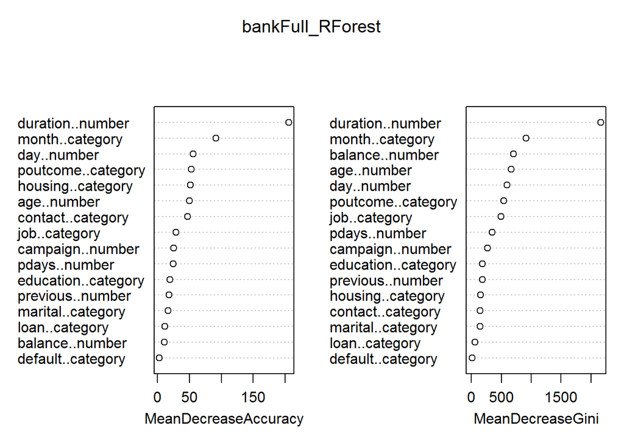

```r
varImpPlot(bankFull_RForest)
```

```r
getResult(bankFull_RForest, "class", bankFull_validate)
```

```
## Confusion Matrix and Statistics
##
##           Reference
## Prediction   no  yes
##        no  3870  280
##        yes  122  248
##
##                Accuracy : 0.9111
##                  95% CI : (0.9024, 0.9192)
##     No Information Rate : 0.8832
##     P-Value [Acc > NIR] : 0.000000000823874033
##
##                   Kappa : 0.5047
##  Mcnemar's Test P-Value : 0.000000000000004861
##
##             Sensitivity : 0.46970
##             Specificity : 0.96944
##          Pos Pred Value : 0.67027
##          Neg Pred Value : 0.93253
##              Prevalence : 0.11681
##          Detection Rate : 0.05487
##    Detection Prevalence : 0.08186
##       Balanced Accuracy : 0.71957
##
##        'Positive' Class : yes
##
```

#### Boosting

Boosting decision tree is another Ensemble model. It fits the decision tree to the entire training set, then add another tree for misclassified observations to the existing tree. Boosting algorithm runs slowly. The sensitivity rate is 43.18%.

```r
# Boosting (Very SLOW use 2 fold cross validation)
library(adabag) #a popular boosting algorithm
set.seed(123)
bankFull_adaboost <- boosting.cv(y..category ~., data=bankFull_train, boos=TRUE, v=2) #.cv is adding cross validation
```

```
## i:  1 Sun Apr 23 22:58:27 2017
## i:  2 Sun Apr 23 23:01:25 2017
```

```r
#don't worry about warning message. Also, this take a while to run.
bankFull_adaboost$confusion #confusion matrix for boosting
```

```
##                Observed Class
## Predicted Class    no   yes
##             no  34678  2584
##             yes  1252  2177
```

```r
bankFull_adaboost$error #error rate for boosting (OOB)
```

```
## [1] 0.09427146
```

```r
bankFull_adaboost_accuracy <- 1 - bankFull_adaboost$error #accuracy rate for boosting (OOB)
bankFull_adaboost_accuracy
```

```
## [1] 0.9057285
```

[Adaboost algorithm in Caret package](https://topepo.github.io/caret/train-models-by-tag.html#boosting)

```r
# Boosting (Very SLOW use 2 fold cross validation)
fitControl <- trainControl(method="cv", number=2)
set.seed(123)
bankFull_boost<-train(y..category ~., data=bankFull_train, method="adaboost", metric="Accuracy", trControl=fitControl)
#summary(bankFull_boost)

getResult(bankFull_boost, "raw", bankFull_validate)
```

```
## Confusion Matrix and Statistics
##
##           Reference
## Prediction   no  yes
##        no  3854  300
##        yes  138  228
##
##                Accuracy : 0.9031
##                  95% CI : (0.8941, 0.9116)
##     No Information Rate : 0.8832
##     P-Value [Acc > NIR] : 0.00001076728218545
##
##                   Kappa : 0.4583
##  Mcnemar's Test P-Value : 0.00000000000001439
##
##             Sensitivity : 0.43182
##             Specificity : 0.96543
##          Pos Pred Value : 0.62295
##          Neg Pred Value : 0.92778
##              Prevalence : 0.11681
##          Detection Rate : 0.05044
##    Detection Prevalence : 0.08097
##       Balanced Accuracy : 0.69862
##
##        'Positive' Class : yes
##
```

### Model 2: Logistic Regression

- Previous marketing campaign success increases the chance of client subscribe a term deposit.
- Last contact during high increases the chance of client subscribe a term deposit while last contact during low decreases the chance of client subscribe a term deposit.
- Unknown contact category decreases the chance client subscribe a term deposit.
- The month of March, June, September, October, December increases the chance client subscribe a term deposit because they have positive estimates.

[Logistic Regression method in caret package](https://topepo.github.io/caret/train-models-by-tag.html#logistic-regression)

```r
# Logistic Regression
bankFull_train <- bankFull[ trainIndex,]
bankFull_validate <- bankFull[ -trainIndex,]

bankFull_train$poutcome..category_success <- ifelse(bankFull_train$poutcome..category=="success",1,0)
bankFull_train$contact..category_unknown <- ifelse(bankFull_train$contact..category=="unknown",1,0)
bankFull_train$duration..number_low <- ifelse(bankFull_train$duration..number<132,1,0)
bankFull_train$duration..number_High <- ifelse(bankFull_train$duration..number>=808,1,0)

bankFull_logit_train <- bankFull_train[,c(11,17:21)]

bankFull_validate$poutcome..category_success <- ifelse(bankFull_validate$poutcome..category=="success",1,0)
bankFull_validate$contact..category_unknown <- ifelse(bankFull_validate$contact..category=="unknown",1,0)
bankFull_validate$duration..number_low <- ifelse(bankFull_validate$duration..number<132,1,0)
bankFull_validate$duration..number_High <- ifelse(bankFull_validate$duration..number>=808 ,1,0)

bankFull_logit_validate <- bankFull_validate[,c(11,17:21)]

fitControl <- trainControl(method = "cv", number = 10)
set.seed(123)
bankFull_lg <- train(y..category ~., data=bankFull_logit_train, method="glm", family="binomial", trControl = fitControl)
summary(bankFull_lg)
```

```
##
## Call:
## NULL
##
## Deviance Residuals:
##     Min       1Q   Median       3Q      Max
## -3.0699  -0.4620  -0.2331  -0.1460   3.5071
##
## Coefficients:
##                            Estimate Std. Error z value
## (Intercept)                -1.43760    0.05593 -25.706
## month..categoryaug         -0.53782    0.07348  -7.319
## month..categorydec          1.02412    0.17998   5.690
## month..categoryfeb         -0.06602    0.08340  -0.792
## month..categoryjan         -0.86561    0.11717  -7.388
## month..categoryjul         -0.82198    0.07429 -11.064
## month..categoryjun          0.55470    0.09029   6.143
## month..categorymar          1.92707    0.12770  15.091
## month..categorymay         -0.54270    0.07140  -7.600
## month..categorynov         -0.74595    0.08361  -8.922
## month..categoryoct          1.19884    0.11110  10.790
## month..categorysep          1.23914    0.12151  10.198
## poutcome..category_success  2.43068    0.06934  35.052
## contact..category_unknown  -1.61173    0.06955 -23.172
## duration..number_low       -2.27658    0.07036 -32.356
## duration..number_High       2.51109    0.05765  43.559
##                                        Pr(>|z|)
## (Intercept)                < 0.0000000000000002 ***
## month..categoryaug           0.0000000000002495 ***
## month..categorydec           0.0000000126947609 ***
## month..categoryfeb                        0.429
## month..categoryjan           0.0000000000001495 ***
## month..categoryjul         < 0.0000000000000002 ***
## month..categoryjun           0.0000000008075620 ***
## month..categorymar         < 0.0000000000000002 ***
## month..categorymay           0.0000000000000295 ***
## month..categorynov         < 0.0000000000000002 ***
## month..categoryoct         < 0.0000000000000002 ***
## month..categorysep         < 0.0000000000000002 ***
## poutcome..category_success < 0.0000000000000002 ***
## contact..category_unknown  < 0.0000000000000002 ***
## duration..number_low       < 0.0000000000000002 ***
## duration..number_High      < 0.0000000000000002 ***
## ---
## Signif. codes:  0 '***' 0.001 '**' 0.01 '*' 0.05 '.' 0.1 ' ' 1
##
## (Dispersion parameter for binomial family taken to be 1)
##
##     Null deviance: 29372  on 40690  degrees of freedom
## Residual deviance: 20860  on 40675  degrees of freedom
## AIC: 20892
##
## Number of Fisher Scoring iterations: 7
```

```r
getResult(bankFull_lg, "raw", bankFull_logit_validate)
```

```
## Confusion Matrix and Statistics
##
##           Reference
## Prediction   no  yes
##        no  3885  329
##        yes  107  199
##
##                Accuracy : 0.9035
##                  95% CI : (0.8946, 0.912)
##     No Information Rate : 0.8832
##     P-Value [Acc > NIR] : 0.000006927
##
##                   Kappa : 0.4282
##  Mcnemar's Test P-Value : < 0.00000000000000022
##
##             Sensitivity : 0.37689
##             Specificity : 0.97320
##          Pos Pred Value : 0.65033
##          Neg Pred Value : 0.92193
##              Prevalence : 0.11681
##          Detection Rate : 0.04403
##    Detection Prevalence : 0.06770
##       Balanced Accuracy : 0.67505
##
##        'Positive' Class : yes
##
```

### Model 3: Neural Network cross validation

[Neural Network in Caret package](https://topepo.github.io/caret/train-models-by-tag.html#neural-network)

```r
bankFull_train <- bankFull[ trainIndex,]
bankFull_validate <- bankFull[ -trainIndex,]

cvControl <- trainControl(method="cv", number=2)
set.seed(123)
bankFull_nn <- train(y..category ~ ., data=bankFull_train, method = "nnet", trControl = cvControl)
#summary(bankFull_nn)
getResult(bankFull_nn, "raw", bankFull_validate)
```

```
## Confusion Matrix and Statistics
##
##           Reference
## Prediction   no  yes
##        no  3814  265
##        yes  178  263
##
##                Accuracy : 0.902
##                  95% CI : (0.893, 0.9105)
##     No Information Rate : 0.8832
##     P-Value [Acc > NIR] : 0.00003108
##
##                   Kappa : 0.4884
##  Mcnemar's Test P-Value : 0.00004389
##
##             Sensitivity : 0.49811
##             Specificity : 0.95541
##          Pos Pred Value : 0.59637
##          Neg Pred Value : 0.93503
##              Prevalence : 0.11681
##          Detection Rate : 0.05819
##    Detection Prevalence : 0.09757
##       Balanced Accuracy : 0.72676
##
##        'Positive' Class : yes
##
```

### ROC curves

The ROC (receiver operating characteristics) curve displays the true positive rate (sensitivity) against the false positive rate (specificity). The Random Forest ROC curve is the best model because it follows the left hand border and then the top left border of the ROC space.

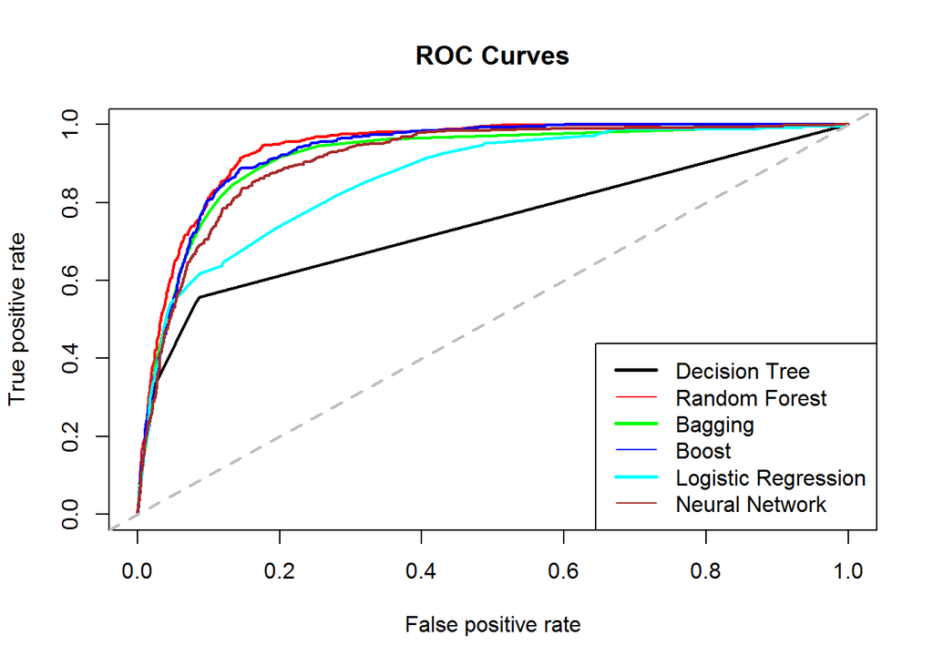

```r
#ROC
#Create a ROC curve
library(ROCR)
R10Fold_predict_prob<-predict(bankFull_10folds, type="prob", bankFull_validate)
R10Fold_pred = prediction(R10Fold_predict_prob[,2], bankFull_validate$y..category)
R10Fold_perf = performance(R10Fold_pred,"tpr", "fpr") #true pos and false pos

RForest_predict_prob<-predict(bankFull_RForest, type="prob", bankFull_validate)
RForest_pred = prediction(RForest_predict_prob[,2], bankFull_validate$y..category)
RForest_perf = performance(RForest_pred,"tpr", "fpr") #true pos and false pos

RBagging_predict_prob<-predict(bankFull_treebag, type="prob", bankFull_validate)
RBagging_pred = prediction(RBagging_predict_prob[,2], bankFull_validate$y..category)
RBagging_perf = performance(RBagging_pred,"tpr", "fpr") #true pos and false pos

RBoost_predict_prob<-predict(bankFull_boost, type="prob", bankFull_validate)
RBoost_pred = prediction(RBoost_predict_prob[,2], bankFull_validate$y..category)
RBoost_perf = performance(RBoost_pred,"tpr", "fpr") #true pos and false pos

RLogit_predict_prob<-predict(bankFull_lg, type="prob", bankFull_logit_validate)
RLogit_pred = prediction(RLogit_predict_prob[,2], bankFull_validate$y..category)
RLogit_perf = performance(RLogit_pred,"tpr", "fpr") #true pos and false pos

RNN_predict_prob<-predict(bankFull_nn, type="prob", bankFull_validate)
RNN_pred = prediction(RNN_predict_prob[,2], bankFull_validate$y..category)
RNN_perf = performance(RNN_pred,"tpr", "fpr") #true pos and false pos


# Start plotting
plot(R10Fold_perf, main="ROC Curves", col="black", lwd=2)
plot(RForest_perf, add=TRUE, col="red", lwd=2)
plot(RBagging_perf, add=TRUE, col="green", lwd=2)
plot(RBoost_perf, add=TRUE, col="blue", lwd=2)
plot(RLogit_perf, add=TRUE, col="cyan", lwd=2)
plot(RNN_perf, add=TRUE, col="brown", lwd=2)
abline(a=0, b=1, lwd=2, lty=2, col="gray")
legend('bottomright', c("Decision Tree", "Random Forest","Bagging", "Boost", "Logistic Regression", "Neural Network"),
       lty=c(1,1), lwd=c(2.5,1), col=c("black","red","green", "blue", "cyan", "brown"))
```

## Summary

At the end of day, we created three different models to estimate the chance of client subscribe term deposit: Decision tree model, Logistic Regression, and Neural Network. *Neural Network has the best sensitivity rate*, *Random Forest has the best ROC curve*. We used variety of ensemble methods (Random Forest, Boosting, Bagging) for decision tree model because a single decision tree model is unstable. All of them have a higher sensitivity rates. Out of all three Ensemble Methods Bagging with ten-fold Cross Validation produced a model with the best sensitivity rate. The decision tree model shows long duration contact, successful marketing campaign, certain month increase term deposit, random forest model show those are important predictors.

| Methods | Sensitivity | Kappa |
| --- | --- | --- |
| Decision Tree | 34.09% | 39.24% |
| DT Bagging | 49.62% | 50.26% |
| DT Random Forest | 46.97% | 50.47% |
| DT Boosting | 43.18% | 45.83% |
| Logistic Regression | 37.69% | 42.82% |
| Neural Network | 49.81% | 48.84% |

- *Bank contacts clients using telephone or cellular more often and longer duration*.
- *Bank does more successful marketing campaigns in month of March, June, September, October, December*.

END